# Análisis sobre la Participación de las mujeres en los parlamentos

Patricia A. Loto

9 de mayo de 2019

## Breve descripción de los datos

| Variable | Clase | Descripción |
| --- | --- | --- |
| pais | caracter | Países incluidos en el dataset |
| camara | caracter | Si los datos corresponden a la cámara `alta`, `baja` o a la cámara `única`. |
| porcentaje_mujeres | numérica | Porcentaje de mujeres en esa cámara (`NA` para el resto de las cámaras) |
| cuota_genero | caracter | Si existe o no cuota de género en esa cámara. (`NA` si no existe información) |
| edad_elegibilidad | numérica | Edad mínima requerida para postular a esa cámara (`NA` si no existe información) |
| integrante_mas_joven | numérica | Integrante más joven en este momento (`NA` si no existe información) |
| numero_integrantes | numérica | Número de integrantes en este momento (`NA` si no existe información) |
| iso_pais | caracter | código ISO del país |

## Librerías necesarias

```r
library(tidyverse)
library(easypackages)
library(janitor)
library(gganimate)
library(gifski)
library(png)
library(LaCroixColoR)
library(extrafont)
library(plotly)
library(treemapify)
```

## Conociendo nuestros datos

```r
dim(datosParlamento)
head(datosParlamento)
tail(datosParlamento)
```

## Limpieza y procesamiento de los datos

A continuación, calcularemos el porcentaje de participación femenina en la Cámara baja o única y en la Cámara Alta en países de Latinoamérica. Y por último, calcularemos el porcentaje de mujeres en parlamentos de Países de Europa.

```r
#----------------------------------------------------------------------------------------------
#CÁMARA BAJA O UNICAMERAL
#----------------------------------------------------------------------------------------------
datosParlamento <- clean_names(datosParlamento)


names(datosParlamento)[8] = "codPais"

#Agrupo por cámara baja o única

camaraBaja<- datosParlamento%>% group_by(codPais, pais)%>% filter (camara =="baja" | camara =="única")%>%
  summarise(totalPorcenCBaja=(sum(porcentaje_mujeres,na.rm = TRUE)), totalIntegrantesCBaja=(sum(numero_integrantes, na.rm = TRUE)))%>%arrange(totalPorcenCBaja)
#View(camaraBaja)

#Panamá aparece sin datos pero en la fuente original si los tienen

# selecciono sólo los que tienen representacion en cámara baja o única
camaraBajaSi <-camaraBaja %>%filter(totalPorcenCBaja>0)
View(camaraBajaSi)

camaraBajaLatam <- filter(camaraBajaSi, pais %in% c("Argentina", "Bolivia" , "Brasil","Chile", "Colombia", "Costa Rica", "Cuba", "Ecuador", "El Salvador", "Guatemala", "Honduras", "México", "Nicaragua", "Panamá", "Paraguay", "Puerto Rico", "Perú", "República Dominicana", "Uruguay", "Venezuela"))
#View(camaraBajaLatam)

#sólo para mejorar la visualización
camaraBajaLatam[camaraBajaLatam$pais == "República Dominicana",2]<-"Rep.Dominicana"

#----------------------------------------------------------------------------------------------
#CÁMARA ALTA O SENADO
#----------------------------------------------------------------------------------------------
#Agrupo por cámara alta o senado
camaraAlta<- datosParlamento%>% group_by(codPais, pais)%>% filter (camara =="alta")%>%
  summarise(totalPorcenCAlta=(sum(porcentaje_mujeres,na.rm = TRUE)), totalIntegrantesCAlta=(sum(datosParlamento$numero_integrantes, na.rm = TRUE)))%>%arrange(totalPorcenCAlta)
#View(camaraAlta)

# selecciono sólo los que tienen representacion en cámara baja o única
camaraAltaSi <-camaraAlta %>%filter(totalPorcenCAlta>0)
View(camaraAltaSi)
# selecciono sólo los países pertenecientes a Latinoamérica
camaraAltaLatam <- filter(camaraAltaSi, pais %in% c("Argentina", "Bolivia" , "Brasil","Chile", "Colombia", "Costa Rica", "Cuba", "Ecuador", "El Salvador", "Guatemala", "Honduras", "México", "Nicaragua", "Panamá", "Paraguay", "Puerto Rico", "Perú", "República Dominicana", "Uruguay", "Venezuela"))%>% arrange(desc(totalPorcenCAlta))
#View(camaraAltaLatam)

#Selecciono los países pertenecientes al continente europeo
camaraAltaEuropa <- filter(camaraAltaSi, pais %in% c("Albania","Alemania","Andorra","Armenia","Austria","Azerbaiyán","Bélgica","Bielorrusia","Bosnia y Herzegovina", "Bulgaria","Chipre", "Croacia", "Dinamarca", "Eslovaquia", "España", "Estonia", "Finlandia",  "Francia",  "Georgia", "Grecia", "Hungría","Irlanda", "Islandia",
                                                     "Italia", "Kazajistán", "Letonia", "Liechtenstein", "Lituania", "Luxemburgo", "Macedonia","Malta", "Moldavia", "Mónaco","Montenegro", "Noruega", "Países Bajos", "Polonia", "Portugal", "Reino Unido", "República Checa", "Rumanía", "Rusia", "San Marino", "Serbia", "Suecia","Suiza", "Turquía", "Ucrania"))
#View(camaraAltaEuropa)
```

## Breve análisis de la presencia parlamentaria de mujeres en Cámara Baja o Única en Países de Latinoámerica.

Nos enfocaremos en averiguar cuáles son los países de nuestra región que cuentan con los niveles más altos y más bajos de participación femenina en su respectivos parlamento, es decir en Cámara baja o Única o en la Cámara Alta o senado.

**¿Cuál es el porcentaje de mujeres en la cámara Baja o Única en países de Latinoamérica?** Mediante las siguientes visualizaciones podremos conocer la situación actual de nuestra región.

#### Visualización nro. 1. Diagramas de barras (barplots)

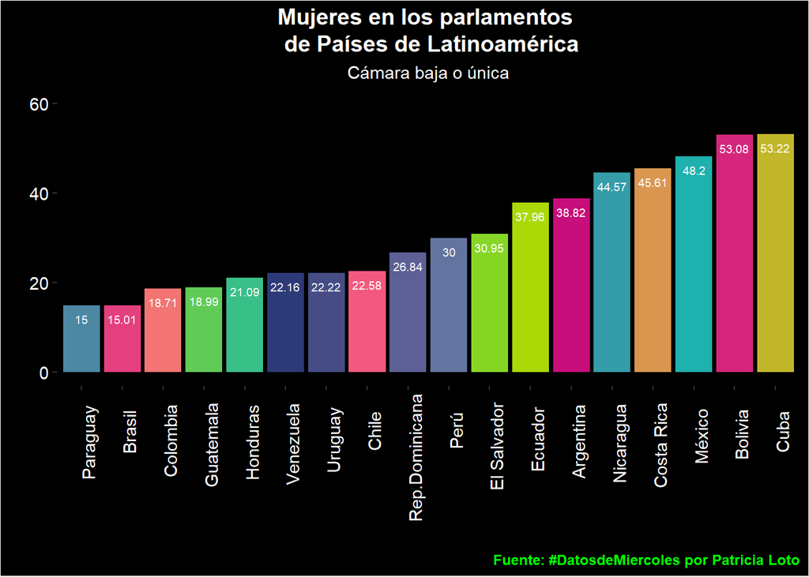

#### Visualización nro. 2. Diagramas de barras horizontales

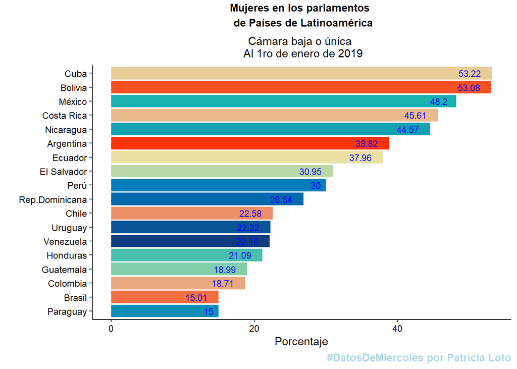

## Presencia parlamentaria de mujeres en Cámara Alta o Senado en Países de Latinoámerica

**¿Cuál es el porcentaje de mujeres en la Cámara Alta o Senado en países de Latinoamérica?**

#### Visualización nro. 3.Diagramas de barras (barplots)

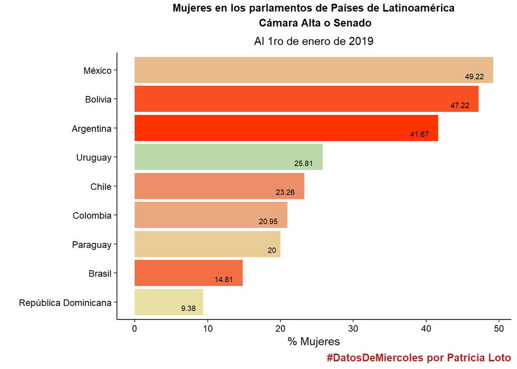

## Presencia parlamentaria de mujeres en Cámara Alta o Senado en países del continente Europeo

Mediante las siguientes visualizaciones podremos conocer la situación actual de las mujeres en los parlamentos europeos.

#### Visualización nro. 4. Treemap

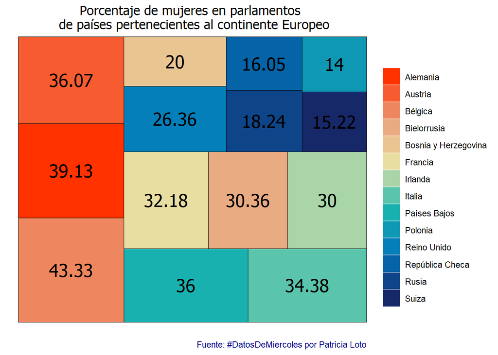

```r
pM5<-lacroix_palette("PeachPear", n = 14, type = "continuous")
treemap<- ggplot(camaraAltaEuropa, aes(area = totalPorcenCAlta, fill = pais,
                                       label =totalPorcenCAlta)) +
  geom_treemap(colour = "black") +
  geom_treemap_text(family="Tahoma",
                    colour = "black",
                    place = "centre",
                    grow = F,
                    reflow = T) +
  scale_fill_manual(values = pM5) +
  labs(fill ="", title = "Porcentaje de mujeres en parlamentos \n de países pertenecientes al continente Europeo", x="", y=" ",
       caption = "Fuente: #DatosDeMiercoles por Patricia Loto") +
  theme_grey() +
  theme(plot.title=element_text(family="Tahoma", hjust=0.5), plot.caption=element_text(family="Palatino", color = "darkblue"), axis.text.x =element_blank(), axis.text.y =element_blank(), axis.ticks.x = element_blank() , axis.ticks.y = element_blank())

ggsave("TreemapParlamentoEuropeo.png",width = 10, height = 5, dpi = "retina")
treemap
```

```r
#agregaAnimación
#treemap +transition_states(pais) +
 # shadow_mark()
```

### Visualización nro. 5.

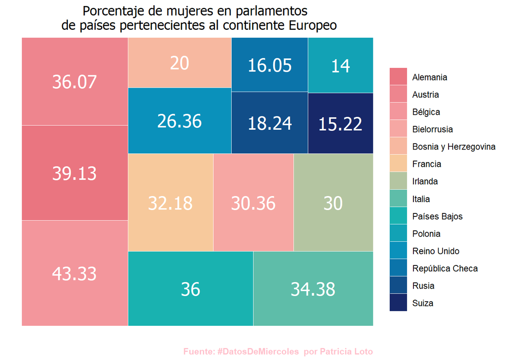

### Resultados.

**A nivel Regional.**

Los países de Latinoamérica con más altos porcentajes de participación con respecto a la **cámara baja** o **única** son:

- Cuba con el 53.22 %
- Bolivia con el 53.08 %
- México con el 48.20 %
- Costa Rica con el 45.61 %
- Nicaragua con el 44.57 % y
- Argentina con el 38.82. Mientras que en las últimas posiciones se encuentran Brasil y Paraguay con el 15.01 y el 15 % respectivamente.

Con respecto a la **cámara alta** o **Senado**, los países de Latinoamérica que llevan la delantera respecto a otros países de la región son: **México**, **Bolivia** y **Argentina** con el 49.22, 47.22 y 41.67% respectivamente. Cabe destacar, que en el último puesto se encuentra República Dominicana con sólo el 9.38 % de participación.

**A Nivel Continente Europeo**

Los países pertenecientes al continente europeo con mayor presencia femenina en los parlamentos son:

- Bélgica con el 43.33 %,
- Alemania con el 39.13 %
- Austria con el 36.07 %
- Países bajos con el 36 %
- Italia con el 34.38 % y
- Francia con el 32.18 %. Por otro lado, en las últimas posiciones se encuentran República Checa, Suiza y Polonia con el 16.05, 15.22 y 14 % respectivamente.

## Consideraciones sobre la Fuente de datos utilizada

Este *dataset* recoge algunos de los datos que se encuentran disponibles en la plataforma de datos abiertos de la Unión Interparlamentaria plataforma de datos abiertos de la Unión Interparlamentaria. Y la selección y traducción al español estuvo a cargo de [Riva Quiroga](https://twitter.com/rivaquiroga).

## Fuentes

- [#DatosDeMiercoles] (https://github.com/cienciadedatos/datos-de-miercoles)

## Notas interesantes sobre Igualdad de Género en la política

- Aplicación shiny sobre mujeres en el parlamento (2000 - 2018) desarrollada por [Gabriela Matthieu](https://twitter.com/calcita13). [Aplicación Shiny](https://calcita.shinyapps.io/women_in_politics)
- [Slides presentación LatinR](https://gitlab.com/calcita/Presenta_mep/blob/master/Presenta_mep.pdf)
- https://laciudaddelasdiosas.wordpress.com/2008/03/06/el-parlamento-europeo-y-la-igualdad-de-genero/
- http://www.oecd.org/gender/data/female-share-of-seats-in-national-parliaments.html
- https://www.elmundo.es/espana/verano/2017/07/30/5978c253e5fdeaf8078b45bb.html
- https://www.nexos.com.mx/?p=40895